# Analyzing My Nutrition/Fitness Data

The pipeline for this project is as follows:

1. Extract, transform, and load data (ETL) from various sources.
2. Preprocess data and engineer features.
3. Analyze and understand data.

We pose the following research questions:

- What is My Body Fat %?
- How much food should I eat to maintain my current physique?
- IIFYM or Counting Calories?

We will use R for the analysis.

```r
# imports
library('stringr')
library(tidyr)
library(car)
library(ALSM)
library(MASS)
library('onewaytests')
library(pheatmap)
library(lmridge)
library('MPV')
library(leaps)
library(caret)
```

## Data Loading

```r
df = read.csv('/Users/amanchopra/Documents/School/College/Spring 2021/STAT 512/Final Project/final_health_data.csv')
head(df)
```

| X | AppleStandTime..min. | BodyFatPercentage.... | Weight..lbs. | BodyMassIndex..count. | FlightsClimbed..count. | HeartRate..bpm. | HeartRateVariability..ms. | OxygenSaturation.... | RestingHeartRate..bpm. | ... | Carbs..g. | Fat..g. | Protein..g. | Sodium..mg. | Sugar..g. | NumWorkouts | TDEE..cal. | TotalExerciseDuration..min. | TotalDistanceTraveled..mi. | RPE |
| --- | --- | --- | --- | --- | --- | --- | --- | --- | --- | --- | --- | --- | --- | --- | --- | --- | --- | --- | --- | --- |
| 2018-05-22 | 236 | 0.09073989 | 145.6792 | 20 | 3 | 88.48567 | 60.19338 | 0.9756478 | 52.40902 | ... | 205 | 64 | 165 | 1986 | 65 | 4 | 2525 | 158.3344 | 1.3622750 | 8 |
| 2018-05-23 | 235 | 0.09034812 | 145.3414 | 20 | 11 | 87.58668 | 60.61022 | 0.9755995 | 52.36940 | ... | 233 | 64 | 179 | 2078 | 67 | 4 | 2525 | 153.4567 | 2.0869865 | 8 |
| 2018-05-24 | 230 | 0.09280581 | 146.8387 | 20 | 10 | 87.17255 | 62.92908 | 0.9755389 | 52.14097 | ... | 327 | NA | 207 | 3244 | NA | 4 | 2525 | 145.7853 | 3.3614567 | 8 |
| 2018-05-25 | 229 | 0.09112916 | 145.7972 | 20 | 13 | 89.58805 | 61.78014 | 0.9756768 | 51.84364 | ... | 300 | 60 | 198 | 2767 | 89 | 3 | 2525 | 158.3231 | 5.2204211 | 8 |
| 2018-05-26 | 236 | 0.09077544 | 145.8391 | 20 | 3 | 88.78992 | 59.97472 | 0.9756445 | 52.42977 | ... | 201 | 56 | 156 | 2074 | 65 | 4 | 2525 | 160.2778 | 0.9437687 | 8 |
| 2018-05-29 | 277 | 0.10493733 | 151.9811 | 21 | 119 | 90.91301 | 52.98293 | 0.9755049 | 53.31815 | ... | 387 | 66 | 228 | 4073 | 123 | 5 | NA | 213.1462 | 9.3257577 | 8 |

## Data Cleaning

Let's clean up the data by dropping the timestamps and formatting the column names.

```r
df = df[,2:length(colnames(df))] # drop timestamp
for (i in 1:length(colnames(df))) {
  colnames(df)[i] = str_replace_all(colnames(df)[i], '\\.+', '.')
  colnames(df)[i] = str_replace_all(colnames(df)[i], '\\.$', '')
}

head(df)
```

| AppleStandTime.min | BodyFatPercentage | Weight.lbs | BodyMassIndex.count | FlightsClimbed.count | HeartRate.bpm | HeartRateVariability.ms | OxygenSaturation | RestingHeartRate.bpm | StepCount.count | ... | Carbs.g | Fat.g | Protein.g | Sodium.mg | Sugar.g | NumWorkouts | TDEE.cal | TotalExerciseDuration.min | TotalDistanceTraveled.mi | RPE |
| --- | --- | --- | --- | --- | --- | --- | --- | --- | --- | --- | --- | --- | --- | --- | --- | --- | --- | --- | --- | --- |
| 236 | 0.09073989 | 145.6792 | 20 | 3 | 88.48567 | 60.19338 | 0.9756478 | 52.40902 | 3502 | ... | 205 | 64 | 165 | 1986 | 65 | 4 | 2525 | 158.3344 | 1.3622750 | 8 |
| 235 | 0.09034812 | 145.3414 | 20 | 11 | 87.58668 | 60.61022 | 0.9755995 | 52.36940 | 5134 | ... | 233 | 64 | 179 | 2078 | 67 | 4 | 2525 | 153.4567 | 2.0869865 | 8 |
| 230 | 0.09280581 | 146.8387 | 20 | 10 | 87.17255 | 62.92908 | 0.9755389 | 52.14097 | 8326 | ... | 327 | NA | 207 | 3244 | NA | 4 | 2525 | 145.7853 | 3.3614567 | 8 |
| 229 | 0.09112916 | 145.7972 | 20 | 13 | 89.58805 | 61.78014 | 0.9756768 | 51.84364 | 12920 | ... | 300 | 60 | 198 | 2767 | 89 | 3 | 2525 | 158.3231 | 5.2204211 | 8 |
| 236 | 0.09077544 | 145.8391 | 20 | 3 | 88.78992 | 59.97472 | 0.9756445 | 52.42977 | 2251 | ... | 201 | 56 | 156 | 2074 | 65 | 4 | 2525 | 160.2778 | 0.9437687 | 8 |
| 277 | 0.10493733 | 151.9811 | 21 | 119 | 90.91301 | 52.98293 | 0.9755049 | 53.31815 | 19639 | ... | 387 | 66 | 228 | 4073 | 123 | 5 | NA | 213.1462 | 9.3257577 | 8 |

Finally, let's drop rows with missing values.

```r
df = na.omit(df)
row.names(df) = NULL
head(df)
```

| AppleStandTime.min | BodyFatPercentage | Weight.lbs | BodyMassIndex.count | FlightsClimbed.count | HeartRate.bpm | HeartRateVariability.ms | OxygenSaturation | RestingHeartRate.bpm | StepCount.count | ... | Carbs.g | Fat.g | Protein.g | Sodium.mg | Sugar.g | NumWorkouts | TDEE.cal | TotalExerciseDuration.min | TotalDistanceTraveled.mi | RPE |
| --- | --- | --- | --- | --- | --- | --- | --- | --- | --- | --- | --- | --- | --- | --- | --- | --- | --- | --- | --- | --- |
| 236 | 0.09073989 | 145.6792 | 20 | 3 | 88.48567 | 60.19338 | 0.9756478 | 52.40902 | 3502 | ... | 205 | 64 | 165 | 1986 | 65 | 4 | 2525 | 158.3344 | 1.3622750 | 8 |
| 235 | 0.09034812 | 145.3414 | 20 | 11 | 87.58668 | 60.61022 | 0.9755995 | 52.36940 | 5134 | ... | 233 | 64 | 179 | 2078 | 67 | 4 | 2525 | 153.4567 | 2.0869865 | 8 |
| 229 | 0.09112916 | 145.7972 | 20 | 13 | 89.58805 | 61.78014 | 0.9756768 | 51.84364 | 12920 | ... | 300 | 60 | 198 | 2767 | 89 | 3 | 2525 | 158.3231 | 5.2204211 | 8 |
| 236 | 0.09077544 | 145.8391 | 20 | 3 | 88.78992 | 59.97472 | 0.9756445 | 52.42977 | 2251 | ... | 201 | 56 | 156 | 2074 | 65 | 4 | 2525 | 160.2778 | 0.9437687 | 8 |
| 295 | 0.10573188 | 152.4333 | 21 | 63 | 92.19074 | 50.83372 | 0.9762484 | 53.04981 | 37696 | ... | 384 | 63 | 230 | 3577 | 118 | 5 | 2525 | 229.6864 | 15.8891365 | 8 |
| 222 | 0.09060918 | 145.8344 | 20 | 8 | 89.47722 | 62.95819 | 0.9773215 | 52.35390 | 11507 | ... | 287 | 59 | 194 | 2510 | 84 | 3 | 2525 | 155.6111 | 4.8668566 | 8 |

**Descriptive Statistics**

```r
print(sprintf('Dimension of Dataset: %d x %d', dim(df)[1], dim(df)[2]))
```

```
[1] "Dimension of Dataset: 681 x 22"
```

```r
summary(df)
```

```
 AppleStandTime.min BodyFatPercentage   Weight.lbs    BodyMassIndex.count
 Min.   :116.0      Min.   :0.06900   Min.   :140.4   Min.   :18.0
 1st Qu.:230.0      1st Qu.:0.09054   1st Qu.:145.5   1st Qu.:20.0
 Median :234.0      Median :0.09144   Median :146.1   Median :20.0
 Mean   :241.8      Mean   :0.09449   Mean   :147.3   Mean   :20.1
 3rd Qu.:243.0      3rd Qu.:0.09624   3rd Qu.:148.2   3rd Qu.:20.0
 Max.   :387.0      Max.   :0.11900   Max.   :159.0   Max.   :22.0
 FlightsClimbed.count HeartRate.bpm    HeartRateVariability.ms OxygenSaturation
 Min.   :  1.00       Min.   : 55.54   Min.   : 14.45          Min.   :0.9300
 1st Qu.:  8.00       1st Qu.: 87.80   1st Qu.: 57.94          1st Qu.:0.9752
 Median : 12.00       Median : 88.83   Median : 60.50          Median :0.9757
 Mean   : 15.56       Mean   : 88.71   Mean   : 59.43          Mean   :0.9758
 3rd Qu.: 17.00       3rd Qu.: 90.03   3rd Qu.: 61.80          3rd Qu.:0.9768
 Max.   :196.00       Max.   :116.16   Max.   :120.09          Max.   :1.0000
 RestingHeartRate.bpm StepCount.count WalkingSpeed.mph    Calories
 Min.   :47.00        Min.   :   65   Min.   :2.377    Min.   : 930
 1st Qu.:51.94        1st Qu.: 8398   1st Qu.:3.228    1st Qu.:2186
 Median :52.29        Median :11941   Median :3.398    Median :2417
 Mean   :52.28        Mean   :12075   Mean   :3.386    Mean   :2453
 3rd Qu.:52.51        3rd Qu.:15026   3rd Qu.:3.511    3rd Qu.:2679
 Max.   :60.00        Max.   :37696   Max.   :4.706    Max.   :6697
    Carbs.g          Fat.g          Protein.g       Sodium.mg
 Min.   : 83.0   Min.   : 13.00   Min.   : 12.0   Min.   :    0
 1st Qu.:239.0   1st Qu.: 58.00   1st Qu.:187.0   1st Qu.: 2172
 Median :293.0   Median : 61.00   Median :195.0   Median : 2585
 Mean   :298.2   Mean   : 62.75   Mean   :197.6   Mean   : 2768
 3rd Qu.:357.0   3rd Qu.: 65.00   3rd Qu.:212.0   3rd Qu.: 3135
 Max.   :934.0   Max.   :247.00   Max.   :302.0   Max.   :11214
    Sugar.g        NumWorkouts       TDEE.cal    TotalExerciseDuration.min
 Min.   :  1.00   Min.   :1.000   Min.   : 572   Min.   : 13.0
 1st Qu.: 70.00   1st Qu.:3.000   1st Qu.:2525   1st Qu.:149.1
 Median : 86.00   Median :4.000   Median :2525   Median :158.9
 Mean   : 89.66   Mean   :3.755   Mean   :2636   Mean   :165.9
 3rd Qu.:106.00   3rd Qu.:4.000   3rd Qu.:2525   3rd Qu.:175.4
 Max.   :406.00   Max.   :8.000   Max.   :4128   Max.   :322.9
 TotalDistanceTraveled.mi      RPE
 Min.   : 0.03021         Min.   : 1.000
 1st Qu.: 3.79278         1st Qu.: 8.000
 Median : 5.43454         Median : 8.000
 Mean   : 5.70429         Mean   : 8.135
 3rd Qu.: 7.06759         3rd Qu.: 8.000
 Max.   :16.62552         Max.   :14.000
```

## Research

### 1. What is My Body Fat %?

High body fat percentage is associated with life-threatening, obesity-related diseases, including heart disease, stroke, high blood pressure, and type 2 diabetes. A healthy body fat percentage is considered to be between 21%-33%.

Expensive weighing scales and procedures like an InBody scan that leverages bioelectrical impedance technology are the current ways to obtain accurate body fat percentage readings. Most people, however, don't own these tools or can't afford them.

In recent years, Clínica Universidad de Navarra in Spain [developed an equation](https://journals.plos.org/plosone/article?id=10.1371/journal.pone.0122291) known as the CUN-BAE equation that predicts body fat from predictors like BMI, age, and sex. The equations is as follows: $\hat{BodyFat\%}=−44.988+0.503*Age+10.689*IsFemale+3.172*BMI-0.026*BMI^2+0.181*BMI*IsFemale-0.02*BMI*Age-0.005*BMI^2*IsFemale+0.00021*BMI^2*Age$.

As of today (4/18), I am a 21-year-old male with a BMI of 21 and true body fat percentage of 11.2933%. The CUN-BAE model predicts ~11.891% for my body fat percentage.

We will attempt to build a model that can predict my body fat percentage with even more accuracy that the CUN-BAE equation.

Let's begin by constructing a full first order model.

```r
full.bf.mod = lm(BodyFatPercentage~., data=df)
summary(full.bf.mod)
```

```
Call:
lm(formula = BodyFatPercentage ~ ., data = df)

Residuals:
       Min         1Q     Median         3Q        Max
-0.0145586 -0.0005597  0.0001079  0.0005883  0.0172530

Coefficients:
                            Estimate Std. Error t value Pr(>|t|)
(Intercept)               -1.514e-01  1.894e-02  -7.990 6.05e-15 ***
AppleStandTime.min         6.027e-06  4.911e-06   1.227 0.220132
Weight.lbs                 1.544e-03  4.906e-05  31.467  < 2e-16 ***
BodyMassIndex.count        2.020e-03  2.611e-04   7.735 3.88e-14 ***
FlightsClimbed.count       1.313e-06  3.818e-06   0.344 0.731046
HeartRate.bpm              2.531e-05  1.863e-05   1.358 0.174807
HeartRateVariability.ms    1.460e-06  1.028e-05   0.142 0.887064
OxygenSaturation          -3.038e-02  1.767e-02  -1.720 0.085914 .
RestingHeartRate.bpm       2.708e-05  6.184e-05   0.438 0.661653
StepCount.count            1.048e-09  5.986e-08   0.018 0.986031
WalkingSpeed.mph          -4.600e-04  2.524e-04  -1.823 0.068819 .
Calories                   1.030e-06  1.279e-06   0.806 0.420648
Carbs.g                    2.146e-06  4.701e-06   0.456 0.648229
Fat.g                     -2.399e-05  1.371e-05  -1.750 0.080612 .
Protein.g                 -9.307e-06  6.418e-06  -1.450 0.147454
Sodium.mg                  2.430e-07  1.249e-07   1.945 0.052186 .
Sugar.g                   -1.094e-06  4.744e-06  -0.231 0.817633
NumWorkouts                2.971e-04  1.052e-04   2.823 0.004896 **
TDEE.cal                  -1.887e-07  3.588e-07  -0.526 0.599087
TotalExerciseDuration.min  1.328e-05  3.760e-06   3.532 0.000441 ***
TotalDistanceTraveled.mi   1.623e-04  1.117e-04   1.453 0.146627
RPE                       -4.099e-05  8.080e-05  -0.507 0.612105
---
Signif. codes:  0 ‘***’ 0.001 ‘**’ 0.01 ‘*’ 0.05 ‘.’ 0.1 ‘ ’ 1

Residual standard error: 0.001646 on 659 degrees of freedom
Multiple R-squared:  0.9411,	Adjusted R-squared:  0.9392
F-statistic: 501.3 on 21 and 659 DF,  p-value: < 2.2e-16
```

```r
red.bf.mod = lm(BodyFatPercentage~Weight.lbs+BodyMassIndex.count+OxygenSaturation+WalkingSpeed.mph+Fat.g+Sodium.mg+NumWorkouts+TotalExerciseDuration.min, data=df)
anova(red.bf.mod, full.bf.mod)
```

| Res.Df | RSS | Df | Sum of Sq | F | Pr(>F) |
| --- | --- | --- | --- | --- | --- |
| 672 | 0.001787903 | NA | NA | NA | NA |
| 659 | 0.001786408 | 13 | 1.494859e-06 | 1.149892e-07 | 0.04324282 |

```r
bf.mod1 = lm(BodyFatPercentage~Weight.lbs+BodyMassIndex.count+OxygenSaturation+WalkingSpeed.mph+Fat.g+Sodium.mg+NumWorkouts+TotalExerciseDuration.min, data=df)
summary(bf.mod1)
```

```
Call:
lm(formula = BodyFatPercentage ~ Weight.lbs + BodyMassIndex.count +
    OxygenSaturation + WalkingSpeed.mph + Fat.g + Sodium.mg +
    NumWorkouts + TotalExerciseDuration.min, data = df)

Residuals:
       Min         1Q     Median         3Q        Max
-0.0144751 -0.0005512  0.0000333  0.0006378  0.0185262

Coefficients:
                            Estimate Std. Error t value Pr(>|t|)
(Intercept)               -1.679e-01  1.801e-02  -9.323  < 2e-16 ***
Weight.lbs                 1.634e-03  4.287e-05  38.121  < 2e-16 ***
BodyMassIndex.count        1.946e-03  2.592e-04   7.508 1.92e-13 ***
OxygenSaturation          -2.074e-02  1.742e-02  -1.191 0.234225
WalkingSpeed.mph          -8.333e-04  2.273e-04  -3.667 0.000265 ***
Fat.g                     -9.272e-06  4.074e-06  -2.276 0.023147 *
Sodium.mg                  5.577e-07  9.348e-08   5.966 3.94e-09 ***
NumWorkouts                1.728e-04  9.771e-05   1.768 0.077448 .
TotalExerciseDuration.min  2.421e-05  2.801e-06   8.644  < 2e-16 ***
---
Signif. codes:  0 ‘***’ 0.001 ‘**’ 0.01 ‘*’ 0.05 ‘.’ 0.1 ‘ ’ 1

Residual standard error: 0.00168 on 672 degrees of freedom
Multiple R-squared:  0.9375,	Adjusted R-squared:  0.9367
F-statistic:  1259 on 8 and 672 DF,  p-value: < 2.2e-16
```

Let's build another model using stepwise model selection.

```r
step(full.bf.mod)
```

```
Start:  AIC=-8707.61
BodyFatPercentage ~ AppleStandTime.min + Weight.lbs + BodyMassIndex.count +
    FlightsClimbed.count + HeartRate.bpm + HeartRateVariability.ms +
    OxygenSaturation + RestingHeartRate.bpm + StepCount.count +
    WalkingSpeed.mph + Calories + Carbs.g + Fat.g + Protein.g +
    Sodium.mg + Sugar.g + NumWorkouts + TDEE.cal + TotalExerciseDuration.min +
    TotalDistanceTraveled.mi + RPE

                            Df  Sum of Sq       RSS     AIC
- StepCount.count            1 0.00000000 0.0017864 -8709.6
- HeartRateVariability.ms    1 0.00000005 0.0017865 -8709.6
- Sugar.g                    1 0.00000014 0.0017866 -8709.6
- FlightsClimbed.count       1 0.00000032 0.0017867 -8709.5
- RestingHeartRate.bpm       1 0.00000052 0.0017869 -8709.4
- Carbs.g                    1 0.00000056 0.0017870 -8709.4
- RPE                        1 0.00000070 0.0017871 -8709.3
- TDEE.cal                   1 0.00000075 0.0017872 -8709.3
- Calories                   1 0.00000176 0.0017882 -8708.9
- AppleStandTime.min         1 0.00000408 0.0017905 -8708.1
- HeartRate.bpm              1 0.00000500 0.0017914 -8707.7
<none>                                    0.0017864 -8707.6
- Protein.g                  1 0.00000570 0.0017921 -8707.4
- TotalDistanceTraveled.mi   1 0.00000573 0.0017921 -8707.4
- OxygenSaturation           1 0.00000802 0.0017944 -8706.6
- Fat.g                      1 0.00000830 0.0017947 -8706.4
- WalkingSpeed.mph           1 0.00000900 0.0017954 -8706.2
- Sodium.mg                  1 0.00001026 0.0017967 -8705.7
- NumWorkouts                1 0.00002161 0.0018080 -8701.4
- TotalExerciseDuration.min  1 0.00003382 0.0018202 -8696.8
- BodyMassIndex.count        1 0.00016220 0.0019486 -8650.4
- Weight.lbs                 1 0.00268420 0.0044706 -8084.9

Step:  AIC=-8709.61
BodyFatPercentage ~ AppleStandTime.min + Weight.lbs + BodyMassIndex.count +
    FlightsClimbed.count + HeartRate.bpm + HeartRateVariability.ms +
    OxygenSaturation + RestingHeartRate.bpm + WalkingSpeed.mph +
    Calories + Carbs.g + Fat.g + Protein.g + Sodium.mg + Sugar.g +
    NumWorkouts + TDEE.cal + TotalExerciseDuration.min + TotalDistanceTraveled.mi +
    RPE

```

[output cut: 225 more lines]

```
    NumWorkouts + TotalExerciseDuration.min + TotalDistanceTraveled.mi

                            Df  Sum of Sq       RSS     AIC
<none>                                    0.0017983 -8723.1
- OxygenSaturation           1 0.00000722 0.0018055 -8722.4
- WalkingSpeed.mph           1 0.00000882 0.0018071 -8721.8
- Protein.g                  1 0.00001676 0.0018150 -8718.8
- Sodium.mg                  1 0.00001992 0.0018182 -8717.6
- NumWorkouts                1 0.00002384 0.0018221 -8716.1
- Calories                   1 0.00002887 0.0018271 -8714.3
- Fat.g                      1 0.00002960 0.0018279 -8714.0
- TotalDistanceTraveled.mi   1 0.00004769 0.0018460 -8707.3
- TotalExerciseDuration.min  1 0.00007157 0.0018698 -8698.5
- BodyMassIndex.count        1 0.00017424 0.0019725 -8662.1
- Weight.lbs                 1 0.00309013 0.0048884 -8044.1
```

```
Call:
lm(formula = BodyFatPercentage ~ Weight.lbs + BodyMassIndex.count +
    OxygenSaturation + WalkingSpeed.mph + Calories + Fat.g +
    Protein.g + Sodium.mg + NumWorkouts + TotalExerciseDuration.min +
    TotalDistanceTraveled.mi, data = df)

Coefficients:
              (Intercept)                 Weight.lbs
               -1.499e-01                  1.538e-03
      BodyMassIndex.count           OxygenSaturation
                2.052e-03                 -2.792e-02
         WalkingSpeed.mph                   Calories
               -4.379e-04                  1.280e-06
                    Fat.g                  Protein.g
               -2.498e-05                 -1.020e-05
                Sodium.mg                NumWorkouts
                3.091e-07                  2.951e-04
TotalExerciseDuration.min   TotalDistanceTraveled.mi
                1.626e-05                  1.864e-04
```

The resulting model with the lowest AIC is $\hat{BodyFatPercentage}=\beta_0+\beta_1*Weight.lbs+\beta_2*BodyMassIndex.count+\beta_3*OxygenSaturation+\beta_4*WalkingSpeed.mph+\beta_5*Fat.g+\beta_6*Sodium.mg+\beta_7*NumWorkouts+\beta_8*TotalExerciseDuation.min+\beta_9*TotalDistanceTraveled.mi+\beta_{10}*Calories+\beta_{11}*Protein.g$.

```r
bf.mod2 = lm(BodyFatPercentage~Weight.lbs+BodyMassIndex.count+OxygenSaturation+WalkingSpeed.mph+Fat.g+Sodium.mg+NumWorkouts+TotalExerciseDuration.min+TotalDistanceTraveled.mi+Calories+Protein.g, data=df)
summary(bf.mod2)
```

```
Call:
lm(formula = BodyFatPercentage ~ Weight.lbs + BodyMassIndex.count +
    OxygenSaturation + WalkingSpeed.mph + Fat.g + Sodium.mg +
    NumWorkouts + TotalExerciseDuration.min + TotalDistanceTraveled.mi +
    Calories + Protein.g, data = df)

Residuals:
       Min         1Q     Median         3Q        Max
-0.0145000 -0.0005313  0.0001081  0.0005636  0.0174073

Coefficients:
                            Estimate Std. Error t value Pr(>|t|)
(Intercept)               -1.499e-01  1.786e-02  -8.394 2.79e-16 ***
Weight.lbs                 1.538e-03  4.537e-05  33.906  < 2e-16 ***
BodyMassIndex.count        2.052e-03  2.549e-04   8.051 3.75e-15 ***
OxygenSaturation          -2.792e-02  1.704e-02  -1.639 0.101772
WalkingSpeed.mph          -4.379e-04  2.417e-04  -1.811 0.070512 .
Fat.g                     -2.498e-05  7.529e-06  -3.319 0.000953 ***
Sodium.mg                  3.091e-07  1.135e-07   2.723 0.006647 **
NumWorkouts                2.951e-04  9.908e-05   2.978 0.003007 **
TotalExerciseDuration.min  1.626e-05  3.152e-06   5.160 3.26e-07 ***
TotalDistanceTraveled.mi   1.864e-04  4.425e-05   4.212 2.88e-05 ***
Calories                   1.280e-06  3.905e-07   3.277 0.001102 **
Protein.g                 -1.020e-05  4.086e-06  -2.497 0.012769 *
---
Signif. codes:  0 ‘***’ 0.001 ‘**’ 0.01 ‘*’ 0.05 ‘.’ 0.1 ‘ ’ 1

Residual standard error: 0.00164 on 669 degrees of freedom
Multiple R-squared:  0.9407,	Adjusted R-squared:  0.9397
F-statistic: 964.6 on 11 and 669 DF,  p-value: < 2.2e-16
```

Finally, let's build a third model using the best subset algorithm.

```r
inp = df[,c(1, 3:22)]
best.subs = BestSub(inp, df$BodyFatPercentage, num=1)
best.subs
```

| p | 1 | 2 | 3 | 4 | 5 | 6 | 7 | 8 | 9 | ... | J | K | L | SSEp | r2 | r2.adj | Cp | AICp | SBCp | PRESSp |
| --- | --- | --- | --- | --- | --- | --- | --- | --- | --- | --- | --- | --- | --- | --- | --- | --- | --- | --- | --- | --- |
| 2 | 0 | 1 | 0 | 0 | 0 | 0 | 0 | 0 | 0 | ... | 0 | 0 | 0 | 0.002584995 | 0.9147455 | 0.9146199 | 276.595858 | -8495.966 | -8486.918 | 0.002608162 |
| 3 | 0 | 1 | 0 | 0 | 0 | 0 | 0 | 0 | 0 | ... | 1 | 0 | 0 | 0.002146897 | 0.9291942 | 0.9289853 | 116.982961 | -8620.427 | -8606.857 | 0.002204634 |
| 4 | 0 | 1 | 1 | 0 | 0 | 0 | 0 | 0 | 0 | ... | 1 | 0 | 0 | 0.002017832 | 0.9334508 | 0.9331559 | 71.371376 | -8660.649 | -8642.555 | 0.002123120 |
| 5 | 0 | 1 | 1 | 0 | 0 | 0 | 0 | 0 | 0 | ... | 1 | 1 | 0 | 0.001910618 | 0.9369868 | 0.9366140 | 33.820471 | -8695.830 | -8673.212 | 0.002028523 |
| 6 | 0 | 1 | 1 | 0 | 0 | 0 | 0 | 0 | 0 | ... | 1 | 1 | 0 | 0.001862545 | 0.9385723 | 0.9381173 | 18.086505 | -8711.184 | -8684.042 | 0.001986969 |
| 7 | 0 | 1 | 1 | 0 | 0 | 0 | 0 | 0 | 0 | ... | 1 | 1 | 0 | 0.001843752 | 0.9391921 | 0.9386508 | 13.153720 | -8716.090 | -8684.425 | 0.001969630 |
| 8 | 0 | 1 | 1 | 0 | 0 | 0 | 0 | 0 | 0 | ... | 1 | 1 | 0 | 0.001826522 | 0.9397603 | 0.9391338 | 8.797834 | -8720.484 | -8684.295 | 0.001962596 |
| 9 | 0 | 1 | 1 | 0 | 0 | 0 | 1 | 0 | 0 | ... | 1 | 1 | 0 | 0.001818532 | 0.9400239 | 0.9393099 | 7.850258 | -8721.469 | -8680.757 | 0.001966520 |
| 10 | 0 | 1 | 1 | 0 | 0 | 0 | 0 | 0 | 0 | ... | 1 | 1 | 0 | 0.001811394 | 0.9402593 | 0.9394580 | 7.217251 | -8722.147 | -8676.912 | 0.001959352 |
| 11 | 0 | 1 | 1 | 0 | 0 | 0 | 1 | 0 | 0 | ... | 1 | 1 | 0 | 0.001804109 | 0.9404995 | 0.9396115 | 6.529727 | -8722.892 | -8673.133 | 0.001963874 |
| 12 | 0 | 1 | 1 | 0 | 0 | 0 | 1 | 0 | 0 | ... | 1 | 1 | 0 | 0.001798265 | 0.9406923 | 0.9397171 | 6.374018 | -8723.101 | -8668.818 | 0.001966871 |
| 13 | 0 | 1 | 1 | 0 | 1 | 0 | 1 | 0 | 0 | ... | 1 | 1 | 0 | 0.001794033 | 0.9408318 | 0.9397689 | 6.812698 | -8722.706 | -8663.900 | 0.001971734 |
| 14 | 1 | 1 | 1 | 0 | 1 | 0 | 1 | 0 | 0 | ... | 1 | 1 | 0 | 0.001790361 | 0.9409530 | 0.9398021 | 7.457952 | -8722.101 | -8658.771 | 0.001990486 |
| 15 | 1 | 1 | 1 | 0 | 1 | 0 | 1 | 0 | 0 | ... | 1 | 1 | 0 | 0.001788790 | 0.9410048 | 0.9397646 | 8.878717 | -8720.699 | -8652.845 | 0.001996520 |
| 16 | 1 | 1 | 1 | 0 | 1 | 0 | 1 | 0 | 0 | ... | 1 | 1 | 1 | 0.001787965 | 0.9410320 | 0.9397019 | 10.574378 | -8719.013 | -8646.636 | 0.002008213 |
| 17 | 1 | 1 | 1 | 0 | 1 | 0 | 1 | 0 | 0 | ... | 1 | 1 | 1 | 0.001787418 | 0.9410500 | 0.9396295 | 12.372429 | -8717.221 | -8640.321 | 0.002015389 |
| 18 | 1 | 1 | 1 | 0 | 1 | 0 | 1 | 1 | 0 | ... | 1 | 1 | 1 | 0.001786978 | 0.9410645 | 0.9395533 | 14.210299 | -8715.389 | -8633.965 | 0.002025300 |
| 19 | 1 | 1 | 1 | 1 | 1 | 0 | 1 | 1 | 0 | ... | 1 | 1 | 1 | 0.001786633 | 0.9410759 | 0.9394737 | 16.083020 | -8713.520 | -8627.573 | 0.002036253 |
| 20 | 1 | 1 | 1 | 1 | 1 | 0 | 1 | 1 | 0 | ... | 1 | 1 | 1 | 0.001786463 | 0.9410815 | 0.9393879 | 18.020228 | -8711.585 | -8621.114 | 0.002045053 |
| 21 | 1 | 1 | 1 | 1 | 1 | 1 | 1 | 1 | 0 | ... | 1 | 1 | 1 | 0.001786409 | 0.9410833 | 0.9392979 | 20.000307 | -8709.606 | -8614.611 | 0.002057852 |
| 22 | 1 | 1 | 1 | 1 | 1 | 1 | 1 | 1 | 1 | ... | 1 | 1 | 1 | 0.001786408 | 0.9410833 | 0.9392058 | 22.000000 | -8707.606 | -8608.088 | 0.002062932 |

```r
metrics = colnames(best.subs)[(length(inp)+2):length(colnames(best.subs))]
mods = 1:length(metrics)
for (j in 1:length(metrics)) {
    if (metrics[j] == 'r2' || metrics[j] == 'r2.adj') {
      preds = best.subs[order(best.subs[,metrics[j]], decreasing=T),][1,1:length(inp)+1]
    } else {
      preds = best.subs[order(best.subs[,metrics[j]]),][1,1:length(inp)+1]
    }
    preds = colnames(inp[which(preds %in% 1)])
    print(sprintf('Metric %s: %s', metrics[j], paste(preds, collapse=', ')))
}
```

```
[1] "Metric SSEp: AppleStandTime.min, Weight.lbs, BodyMassIndex.count, FlightsClimbed.count, HeartRate.bpm, HeartRateVariability.ms, OxygenSaturation, RestingHeartRate.bpm, StepCount.count, WalkingSpeed.mph, Calories, Carbs.g, Fat.g, Protein.g, Sodium.mg, Sugar.g, NumWorkouts, TDEE.cal, TotalExercis…
[1] "Metric r2: AppleStandTime.min, Weight.lbs, BodyMassIndex.count, FlightsClimbed.count, HeartRate.bpm, HeartRateVariability.ms, OxygenSaturation, RestingHeartRate.bpm, StepCount.count, WalkingSpeed.mph, Calories, Carbs.g, Fat.g, Protein.g, Sodium.mg, Sugar.g, NumWorkouts, TDEE.cal, TotalExerciseD…
[1] "Metric r2.adj: AppleStandTime.min, Weight.lbs, BodyMassIndex.count, HeartRate.bpm, OxygenSaturation, WalkingSpeed.mph, Calories, Fat.g, Protein.g, Sodium.mg, NumWorkouts, TotalExerciseDuration.min, TotalDistanceTraveled.mi"
[1] "Metric Cp: Weight.lbs, BodyMassIndex.count, OxygenSaturation, WalkingSpeed.mph, Calories, Fat.g, Protein.g, Sodium.mg, NumWorkouts, TotalExerciseDuration.min, TotalDistanceTraveled.mi"
[1] "Metric AICp: Weight.lbs, BodyMassIndex.count, OxygenSaturation, WalkingSpeed.mph, Calories, Fat.g, Protein.g, Sodium.mg, NumWorkouts, TotalExerciseDuration.min, TotalDistanceTraveled.mi"
[1] "Metric SBCp: Weight.lbs, BodyMassIndex.count, Carbs.g, Fat.g, TotalExerciseDuration.min, TotalDistanceTraveled.mi"
[1] "Metric PRESSp: Weight.lbs, BodyMassIndex.count, WalkingSpeed.mph, Carbs.g, Fat.g, Sodium.mg, NumWorkouts, TotalExerciseDuration.min, TotalDistanceTraveled.mi"
```

Let's choose the model with the lowest $PRESS_p$, since prediction is an important goal.

```r
bf.mod3 = lm(BodyFatPercentage~Weight.lbs+BodyMassIndex.count+WalkingSpeed.mph+Carbs.g+Fat.g+Sodium.mg+NumWorkouts+TotalExerciseDuration.min+TotalDistanceTraveled.mi, data=df)
summary(bf.mod3)
```

```
Call:
lm(formula = BodyFatPercentage ~ Weight.lbs + BodyMassIndex.count +
    WalkingSpeed.mph + Carbs.g + Fat.g + Sodium.mg + NumWorkouts +
    TotalExerciseDuration.min + TotalDistanceTraveled.mi, data = df)

Residuals:
       Min         1Q     Median         3Q        Max
-0.0147264 -0.0005408  0.0000921  0.0006050  0.0176072

Coefficients:
                            Estimate Std. Error t value Pr(>|t|)
(Intercept)               -1.802e-01  5.076e-03 -35.499  < 2e-16 ***
Weight.lbs                 1.566e-03  4.444e-05  35.230  < 2e-16 ***
BodyMassIndex.count        1.978e-03  2.527e-04   7.827 1.95e-14 ***
WalkingSpeed.mph          -4.179e-04  2.326e-04  -1.797 0.072852 .
Carbs.g                    4.310e-06  1.426e-06   3.022 0.002603 **
Fat.g                     -1.347e-05  4.823e-06  -2.793 0.005374 **
Sodium.mg                  2.368e-07  1.120e-07   2.114 0.034926 *
NumWorkouts                2.647e-04  9.823e-05   2.695 0.007214 **
TotalExerciseDuration.min  1.640e-05  3.157e-06   5.196 2.71e-07 ***
TotalDistanceTraveled.mi   1.620e-04  4.349e-05   3.725 0.000212 ***
---
Signif. codes:  0 ‘***’ 0.001 ‘**’ 0.01 ‘*’ 0.05 ‘.’ 0.1 ‘ ’ 1

Residual standard error: 0.001643 on 671 degrees of freedom
Multiple R-squared:  0.9403,	Adjusted R-squared:  0.9395
F-statistic:  1173 on 9 and 671 DF,  p-value: < 2.2e-16
```

Now that we have 4 models (including the original full first-order model), let's perform cross validation to select the best model.

```r
train.control = trainControl(method='cv', number=5)

mod1 = train(BodyFatPercentage~., data=df, method='leapBackward', tuneGrid=data.frame(nvmax=21), trControl=train.control)
mod1$results

mod2 = train(BodyFatPercentage~Weight.lbs+BodyMassIndex.count+OxygenSaturation+WalkingSpeed.mph+Fat.g+Sodium.mg+NumWorkouts+TotalExerciseDuration.min, data=df, method='leapBackward', tuneGrid=data.frame(nvmax=8), trControl=train.control)
mod2$results

mod3 = train(BodyFatPercentage~Weight.lbs+BodyMassIndex.count+OxygenSaturation+WalkingSpeed.mph+Fat.g+Sodium.mg+NumWorkouts+TotalExerciseDuration.min+TotalDistanceTraveled.mi+Calories+Protein.g, data=df, method='leapBackward', tuneGrid=data.frame(nvmax=11), trControl=train.control)
mod3$results

mod4 = train(BodyFatPercentage~Weight.lbs+BodyMassIndex.count+WalkingSpeed.mph+Carbs.g+Fat.g+Sodium.mg+NumWorkouts+TotalExerciseDuration.min+TotalDistanceTraveled.mi, data=df, method='leapBackward', tuneGrid=data.frame(nvmax=9), trControl=train.control)
mod4$results
```

| nvmax | RMSE | Rsquared | MAE | RMSESD | RsquaredSD | MAESD |
| --- | --- | --- | --- | --- | --- | --- |
| 21 | 0.001718528 | 0.9314211 | 0.001002428 | 0.0005215483 | 0.03693447 | 0.0001650406 |

| nvmax | RMSE | Rsquared | MAE | RMSESD | RsquaredSD | MAESD |
| --- | --- | --- | --- | --- | --- | --- |
| 8 | 0.001707691 | 0.9330192 | 0.0009600009 | 0.0004378383 | 0.03392046 | 9.128225e-05 |

| nvmax | RMSE | Rsquared | MAE | RMSESD | RsquaredSD | MAESD |
| --- | --- | --- | --- | --- | --- | --- |
| 11 | 0.001627285 | 0.9394845 | 0.0009415175 | 0.000421734 | 0.02905622 | 9.04787e-05 |

| nvmax | RMSE | Rsquared | MAE | RMSESD | RsquaredSD | MAESD |
| --- | --- | --- | --- | --- | --- | --- |
| 9 | 0.001640039 | 0.9385534 | 0.0009595216 | 0.0005353768 | 0.03381226 | 9.008667e-05 |

The third model seems to be the best according to $RMSE$ and $R^2$ on validation data during 5-fold CV, so this will be our final model.

```r
final.bf.mod = lm(BodyFatPercentage~Weight.lbs+BodyMassIndex.count+OxygenSaturation+WalkingSpeed.mph+Fat.g+Sodium.mg+NumWorkouts+TotalExerciseDuration.min+TotalDistanceTraveled.mi+Calories+Protein.g, data=df)
summary(final.bf.mod)
```

```
Call:
lm(formula = BodyFatPercentage ~ Weight.lbs + BodyMassIndex.count +
    OxygenSaturation + WalkingSpeed.mph + Fat.g + Sodium.mg +
    NumWorkouts + TotalExerciseDuration.min + TotalDistanceTraveled.mi +
    Calories + Protein.g, data = df)

Residuals:
       Min         1Q     Median         3Q        Max
-0.0145000 -0.0005313  0.0001081  0.0005636  0.0174073

Coefficients:
                            Estimate Std. Error t value Pr(>|t|)
(Intercept)               -1.499e-01  1.786e-02  -8.394 2.79e-16 ***
Weight.lbs                 1.538e-03  4.537e-05  33.906  < 2e-16 ***
BodyMassIndex.count        2.052e-03  2.549e-04   8.051 3.75e-15 ***
OxygenSaturation          -2.792e-02  1.704e-02  -1.639 0.101772
WalkingSpeed.mph          -4.379e-04  2.417e-04  -1.811 0.070512 .
Fat.g                     -2.498e-05  7.529e-06  -3.319 0.000953 ***
Sodium.mg                  3.091e-07  1.135e-07   2.723 0.006647 **
NumWorkouts                2.951e-04  9.908e-05   2.978 0.003007 **
TotalExerciseDuration.min  1.626e-05  3.152e-06   5.160 3.26e-07 ***
TotalDistanceTraveled.mi   1.864e-04  4.425e-05   4.212 2.88e-05 ***
Calories                   1.280e-06  3.905e-07   3.277 0.001102 **
Protein.g                 -1.020e-05  4.086e-06  -2.497 0.012769 *
---
Signif. codes:  0 ‘***’ 0.001 ‘**’ 0.01 ‘*’ 0.05 ‘.’ 0.1 ‘ ’ 1

Residual standard error: 0.00164 on 669 degrees of freedom
Multiple R-squared:  0.9407,	Adjusted R-squared:  0.9397
F-statistic: 964.6 on 11 and 669 DF,  p-value: < 2.2e-16
```

Let's perform diagnostics on this model to ensure no assumptions have been violated.

**Residual Plots**

```r
# function for changing plotsize
fig = function(width, heigth){options(repr.plot.width = width, repr.plot.height = heigth)} # function to set figsize
```

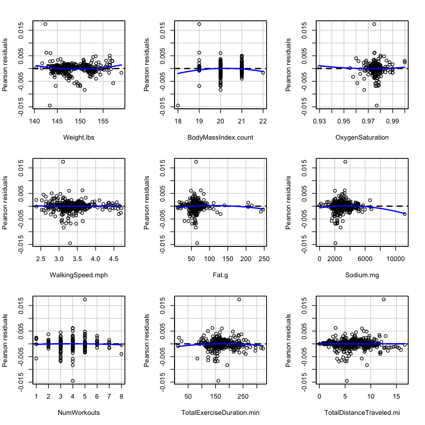

```
                          Test stat Pr(>|Test stat|)
Weight.lbs                   3.0463         0.002408 **
BodyMassIndex.count         -2.9234         0.003580 **
OxygenSaturation             0.9414         0.346836
WalkingSpeed.mph             0.4960         0.620069
Fat.g                       -1.8271         0.068134 .
Sodium.mg                   -2.3516         0.018982 *
NumWorkouts                 -0.7439         0.457217
TotalExerciseDuration.min   -1.8589         0.063481 .
TotalDistanceTraveled.mi     0.1600         0.872957
Calories                    -2.7158         0.006783 **
Protein.g                    1.1134         0.265954
Tukey test                   0.6848         0.493499
---
Signif. codes:  0 ‘***’ 0.001 ‘**’ 0.01 ‘*’ 0.05 ‘.’ 0.1 ‘ ’ 1
```

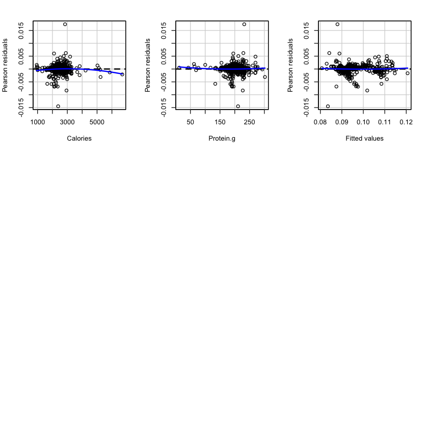

```r
fig(7, 7)
residualPlots(final.bf.mod)
```

**Constant Variance**

```r
for (X in names(coef(final.bf.mod))[2:8]) {
    groups = cut(df[,X], 5)
    resid = final.bf.mod$residuals
    test = bf.test(resid~groups, data=data.frame(groups, resid), verbose=F)
    if (is.na(test$p.value)) {
        print(sprintf('%s: p=NAN', X, test$p.value))
    } else if (test$p.value < 0.05) {
        print(sprintf('%s: variance is constant with p=%f', X, test$p.value))
    } else {
        print(sprintf('%s: variance is NOT constant with p=%f', X, test$p.value))
    }
}
```

```
[1] "Weight.lbs: variance is NOT constant with p=0.302637"
[1] "BodyMassIndex.count: p=NAN"
[1] "OxygenSaturation: p=NAN"
[1] "WalkingSpeed.mph: variance is NOT constant with p=0.088616"
[1] "Fat.g: variance is NOT constant with p=0.241457"
[1] "Sodium.mg: p=NAN"
[1] "NumWorkouts: variance is NOT constant with p=0.119910"
```

The residuals don't seem to have constant variance according to the above residual plots and Brown-Forsythe tests.

**Normality of Residuals**

```r
shapiro.test(final.bf.mod$residuals)
```

```
	Shapiro-Wilk normality test

data:  final.bf.mod$residuals
W = 0.74561, p-value < 2.2e-16
```

The residuals don't seem normally distributed according to the shapiro test with $p\approx0$.

**Outliers and Influential Points**

|  | StudRes | Hat | CookD |
| --- | --- | --- | --- |
| 443 | -9.8602143 | 0.07976414 | 0.61395650 |
| 464 | -1.4831058 | 0.24972452 | 0.06090113 |
| 482 | 12.1407834 | 0.06784576 | 0.73350532 |
| 617 | 0.4793238 | 0.23929890 | 0.00602981 |

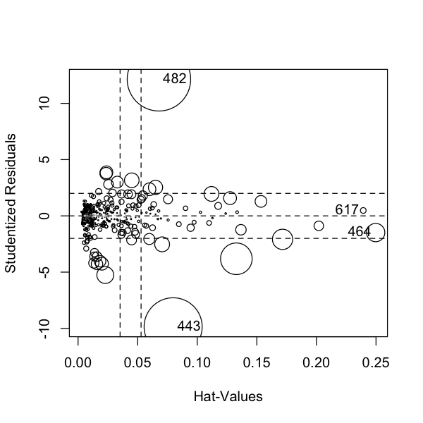

```r
fig(5, 5)
infl.pts = influencePlot(final.bf.mod)
infl.pts
```

**Multicollinearity**

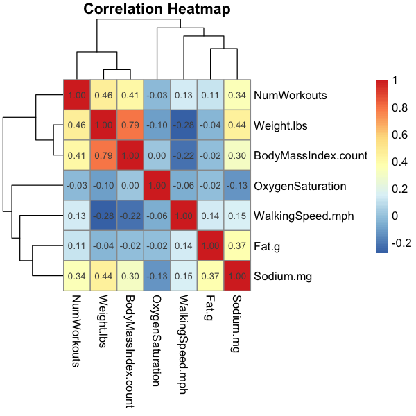

```r
fig(5, 5)
pheatmap(cor(df[names(coef(final.bf.mod))[2:8]]), display_numbers = T, main='Correlation Heatmap')
```

The diagnostics suggest the following:

- The Shapiro test suggests that the residuals are not normally distributed, which suggests that $Y$ should be transformed.
- There are 4 clear influential points considering Cook's distances. Since our dataset is quite large, we will drop these points.
- Multicollinearity seems to be an issue between $Weight.lbs$ and $BodyMassIndex.count$, so we can add an interaction term.

Let's begin by dropping influential points.

```r
df.inf.dropped = df[-as.integer(rownames(infl.pts)),]
```

Now, let's transform $Y$ using the boxcox method.

-0.0909090909090908

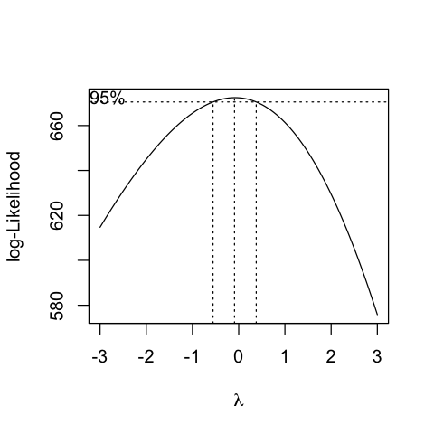

```r
fig(4, 4)
bcmle = boxcox(BodyFatPercentage~Weight.lbs+BodyMassIndex.count+OxygenSaturation+WalkingSpeed.mph+Fat.g+Sodium.mg+NumWorkouts+TotalExerciseDuration.min+TotalDistanceTraveled.mi+Calories+Protein.g, data=df.inf.dropped, lambda=seq(-3, 3, by=0.1))
l = bcmle$x[which.max(bcmle$y)]
l
```

```r
trans.mod = lm(BodyFatPercentage^l~Weight.lbs+BodyMassIndex.count+OxygenSaturation+WalkingSpeed.mph+Fat.g+Sodium.mg+NumWorkouts+TotalExerciseDuration.min+TotalDistanceTraveled.mi+Calories+Protein.g+Weight.lbs*BodyMassIndex.count, data=df.inf.dropped)
summary(trans.mod)
```

```
Call:
lm(formula = BodyFatPercentage^l ~ Weight.lbs + BodyMassIndex.count +
    OxygenSaturation + WalkingSpeed.mph + Fat.g + Sodium.mg +
    NumWorkouts + TotalExerciseDuration.min + TotalDistanceTraveled.mi +
    Calories + Protein.g + Weight.lbs * BodyMassIndex.count,
    data = df.inf.dropped)

Residuals:
       Min         1Q     Median         3Q        Max
-0.0077883 -0.0007246 -0.0001225  0.0005297  0.0097973

Coefficients:
                                 Estimate Std. Error t value Pr(>|t|)
(Intercept)                     1.688e+00  1.324e-01  12.750  < 2e-16 ***
Weight.lbs                     -2.894e-03  8.670e-04  -3.338 0.000891 ***
BodyMassIndex.count            -9.410e-03  6.344e-03  -1.483 0.138477
OxygenSaturation                2.215e-02  1.924e-02   1.151 0.250100
WalkingSpeed.mph                2.254e-04  2.408e-04   0.936 0.349632
Fat.g                           2.519e-05  7.451e-06   3.381 0.000765 ***
Sodium.mg                      -3.243e-07  1.162e-07  -2.792 0.005390 **
NumWorkouts                    -2.271e-04  9.918e-05  -2.290 0.022359 *
TotalExerciseDuration.min      -1.809e-05  3.135e-06  -5.770 1.21e-08 ***
TotalDistanceTraveled.mi       -1.678e-04  4.411e-05  -3.804 0.000155 ***
Calories                       -1.482e-06  4.070e-07  -3.641 0.000293 ***
Protein.g                       1.149e-05  4.151e-06   2.768 0.005790 **
Weight.lbs:BodyMassIndex.count  5.070e-05  4.265e-05   1.189 0.235016
---
Signif. codes:  0 ‘***’ 0.001 ‘**’ 0.01 ‘*’ 0.05 ‘.’ 0.1 ‘ ’ 1

Residual standard error: 0.001618 on 664 degrees of freedom
Multiple R-squared:  0.9544,	Adjusted R-squared:  0.9536
F-statistic:  1158 on 12 and 664 DF,  p-value: < 2.2e-16
```

Now, that we have our final model, let's compare the model prediction to the CUN-BAE equation (predicts 11.891%). As of today (4/18), this is the data I have collected:

- Weight = 155 lbs
- BMI = 21
- Oxygen Saturation = 97.8%
- Walking Speed = 2.8
- Fat Consumption = 53 g
- Sodium Consumption = 4,500 mg
- Number of Workouts = 4
- Total Exercise Duration = 208 min
- Total Distance Traveled = 12.03 mi
- Calories = 3,489
- Protein Consumption = 234 g
- True Body Fat Percentage = 11.2933%

```r
new.data = data.frame(matrix(c(230, 0.112933, 155, 21, 11, 89.32782, 59.32892, 0.978, 51, 31098, 2.8, 3489, 481, 53, 234, 4500, 97, 4, 3288, 208, 12.03, 7), nrow=1, ncol=22))
colnames(new.data) = colnames(df)
new.data
```

| AppleStandTime.min | BodyFatPercentage | Weight.lbs | BodyMassIndex.count | FlightsClimbed.count | HeartRate.bpm | HeartRateVariability.ms | OxygenSaturation | RestingHeartRate.bpm | StepCount.count | ... | Carbs.g | Fat.g | Protein.g | Sodium.mg | Sugar.g | NumWorkouts | TDEE.cal | TotalExerciseDuration.min | TotalDistanceTraveled.mi | RPE |
| --- | --- | --- | --- | --- | --- | --- | --- | --- | --- | --- | --- | --- | --- | --- | --- | --- | --- | --- | --- | --- |
| 230 | 0.112933 | 155 | 21 | 11 | 89.32782 | 59.32892 | 0.978 | 51 | 31098 | ... | 481 | 53 | 234 | 4500 | 97 | 4 | 3288 | 208 | 12.03 | 7 |

```r
predict(trans.mod, new.data)^(1/l)
conf.int = ci.reg(final.bf.mod, data.frame(155, 21, 0.978, 2.8, 53, 4500, 4, 208, 12.03, 2489, 234, 1129), type='m', alpha=0.05)
conf.int[1, 'Lower.Band'] = conf.int[1, 'Lower.Band']^(1/l)
conf.int[1, 'Upper.Band'] = conf.int[1, 'Upper.Band']^(1/l)
conf.int[c('Fit', 'Lower.Band', 'Upper.Band')]
```

**1:** 0.112483325329308

| Fit | Lower.Band | Upper.Band |
| --- | --- | --- |
| 11.24833 | 9.288 | 12.491 |

The model predicts that my body fat percentage is 11.248% (95% mean response confidence interval between 9.288% and 12.491%), while my true body fat is 11.293%. The CUN-BAE equation predicts 11.891%. This model seems to result in a more accurate prediction!

Some potential issues include the following:

### 2. How much food should I eat to maintain my current physique?

Many people use total daily energy expenditure (TDEE) calculators, such as [this](https://tdeecalculator.net/) one, to gauge how many calories they should eat depending on their fitness goals. For example, to lose weight, one should be in a caloric deficit. To gain muscle at a faster rate, one should be in a caloric surplus. Finally, to maintain weight, one should eat at their TDEE.

Most TDEE calculators rely on gender, age, weight, daily activity level (on a scale of 1-5), and body fat to predict TDEE. These indicators are quite generic. Let's try to build a custom, more precise TDEE calculator that considers additional factors (e.g. workout intensity, heart rate, BMI, etc.) and is better personalized for my body.

According to many publications, such as [this](https://cathe.com/5-most-important-factors-that-affect-total-daily-energy-expenditure/), these are the main factors that affect TDEE.

- age
- weight
- sex
- body fat
- physical activity (active heart rate, number of workouts, exercise duration, RPE)
- non-exercise activity thermogenesis (based on resting heart rate)

Let's begin by scaling our data. This will lead to the loss function being optimized faster, and all predictors will have the same scale.

```r
scaled.df = cbind(as.data.frame(scale(cbind(df[,colnames(df)[1:18]], df[,colnames(df)[20:22]]))), df[,'TDEE.cal'])
colnames(scaled.df)[22] = 'TDEE.cal'
```

Now, we will build a first-order model using these predictors.

```r
tdee.mod = lm(TDEE.cal~Weight.lbs+BodyFatPercentage+HeartRate.bpm+RestingHeartRate.bpm+NumWorkouts+TotalExerciseDuration.min+RPE, data=scaled.df)
summary(tdee.mod)
```

```
Call:
lm(formula = TDEE.cal ~ Weight.lbs + BodyFatPercentage + HeartRate.bpm +
    RestingHeartRate.bpm + NumWorkouts + TotalExerciseDuration.min +
    RPE, data = scaled.df)

Residuals:
     Min       1Q   Median       3Q      Max
-1420.24   -77.30   -10.58    52.67  1132.43

Coefficients:
                          Estimate Std. Error t value Pr(>|t|)
(Intercept)               2636.189      8.296 317.767  < 2e-16 ***
Weight.lbs                 115.813     29.085   3.982 7.58e-05 ***
BodyFatPercentage           23.573     31.348   0.752 0.452327
HeartRate.bpm               36.364     10.152   3.582 0.000365 ***
RestingHeartRate.bpm         9.608      9.063   1.060 0.289463
NumWorkouts                -23.095     10.570  -2.185 0.029231 *
TotalExerciseDuration.min   65.580     13.663   4.800 1.96e-06 ***
RPE                         76.470      9.021   8.477  < 2e-16 ***
---
Signif. codes:  0 ‘***’ 0.001 ‘**’ 0.01 ‘*’ 0.05 ‘.’ 0.1 ‘ ’ 1

Residual standard error: 216.5 on 673 degrees of freedom
Multiple R-squared:  0.5331,	Adjusted R-squared:  0.5282
F-statistic: 109.8 on 7 and 673 DF,  p-value: < 2.2e-16
```

Let's perform diagnostics to ensure that MLR assumptions are not violated.

**Residual Plots**

```
                          Test stat Pr(>|Test stat|)
Weight.lbs                   7.5601        1.325e-13 ***
BodyFatPercentage            5.9783        3.661e-09 ***
HeartRate.bpm               12.2861        < 2.2e-16 ***
RestingHeartRate.bpm         8.3157        5.066e-16 ***
NumWorkouts                  7.1161        2.856e-12 ***
TotalExerciseDuration.min    6.8653        1.511e-11 ***
RPE                          9.9195        < 2.2e-16 ***
Tukey test                   8.9415        < 2.2e-16 ***
---
Signif. codes:  0 ‘***’ 0.001 ‘**’ 0.01 ‘*’ 0.05 ‘.’ 0.1 ‘ ’ 1
```

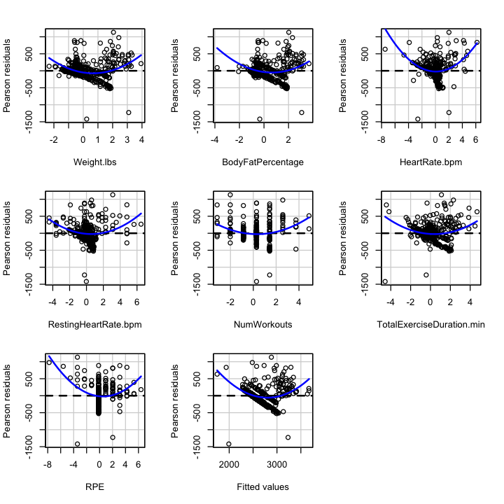

```r
fig(6, 6)
residualPlots(tdee.mod)
```

**Constant Variance**

```r
for (X in names(coef(tdee.mod))[2:8]) {
    groups = cut(df[,X], 5)
    resid = tdee.mod$residuals
    test = bf.test(resid~groups, data=data.frame(groups, resid), verbose=F)
    if (is.na(test$p.value)) {
        print(sprintf('%s: p=NAN', X, test$p.value))
    } else if (test$p.value < 0.05) {
        print(sprintf('%s: variance is constant with p=%f', X, test$p.value))
    } else {
        print(sprintf('%s: variance is NOT constant with p=%f', X, test$p.value))
    }
}
```

```
[1] "Weight.lbs: variance is constant with p=0.000488"
[1] "BodyFatPercentage: p=NAN"
[1] "HeartRate.bpm: p=NAN"
[1] "RestingHeartRate.bpm: variance is constant with p=0.000009"
[1] "NumWorkouts: variance is constant with p=0.000000"
[1] "TotalExerciseDuration.min: variance is NOT constant with p=0.472898"
[1] "RPE: variance is constant with p=0.000126"
```

**Normality of Residuals**

```r
shapiro.test(tdee.mod$residuals)
```

```
	Shapiro-Wilk normality test

data:  tdee.mod$residuals
W = 0.84647, p-value < 2.2e-16
```

The residuals don't seem normally distributed according to the shapiro test with $p \approx 0$.

**Outliers and Influential Points**

|  | StudRes | Hat | CookD |
| --- | --- | --- | --- |
| 443 | 0.4726606 | 0.15429363 | 0.005100804 |
| 482 | -0.7150203 | 0.18781588 | 0.014789045 |
| 595 | -7.1017642 | 0.08400552 | 0.538609142 |
| 653 | 4.9408358 | 0.13702093 | 0.468216163 |
| 681 | -5.9785078 | 0.05364166 | 0.240814141 |

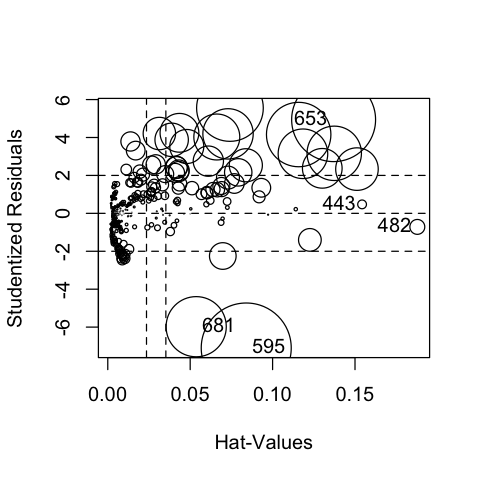

```r
fig(4, 4)
infl.pts = influencePlot(tdee.mod)
infl.pts
```

**Multicollinearity**

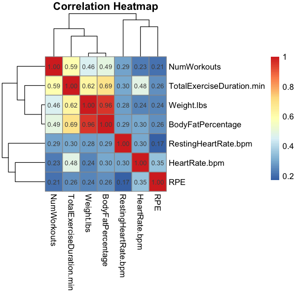

```r
fig(5, 5)
pheatmap(cor(df[names(coef(tdee.mod))[2:8]]), display_numbers = T, main='Correlation Heatmap')
```

The diagnostics suggest the following:

- Constant variance seems to be violated for $TotalExerciseDuration.min$ according to the Brown-Forsythe tests and residual plots. A transformation on $Y$ should be applied.
- The Shapiro test suggests that the residuals are not normally distributed, which also indicates that $Y$ should be transformed.
- There are 5 clear influential points. Since our dataset is quite large, we will drop these points.
- Multicollinearity seems to be an issue, so we can add interaction terms for the strongly correlated predictors ($Weight.lbs$ and $BodyFatPercentage$).

Let's begin by dropping influential points.

```r
df.inf.dropped = scaled.df[-as.integer(rownames(infl.pts)),]
```

Now, we can transform $Y$ using the boxcox method.

-11.6

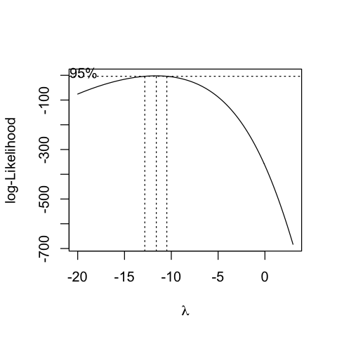

```r
fig(4, 4)
bcmle = boxcox(TDEE.cal~Weight.lbs+BodyFatPercentage+HeartRate.bpm+RestingHeartRate.bpm+NumWorkouts+TotalExerciseDuration.min+RPE, data=df.inf.dropped, lambda=seq(-20, 3, by=0.1))
l = bcmle$x[which.max(bcmle$y)]
l
```

Since lambda is such a negative value, $TDEE.cal$ will shrink towards 0, as applying the transformation will produce $TDEE.cal^{-11.6}$. This will result in a meaningless model with slopes of 0, as we can see below.

```r
trans.mod = lm(TDEE.cal^l~Weight.lbs+BodyFatPercentage+HeartRate.bpm+RestingHeartRate.bpm+NumWorkouts+TotalExerciseDuration.min+RPE, data=df.inf.dropped)
summary(trans.mod)
```

```
Call:
lm(formula = TDEE.cal^l ~ Weight.lbs + BodyFatPercentage + HeartRate.bpm +
    RestingHeartRate.bpm + NumWorkouts + TotalExerciseDuration.min +
    RPE, data = df.inf.dropped)

Residuals:
       Min         1Q     Median         3Q        Max
-3.231e-40 -2.188e-41 -3.160e-42  5.295e-41  2.863e-40

Coefficients:
                            Estimate Std. Error t value Pr(>|t|)
(Intercept)                3.020e-40  3.777e-42  79.964  < 2e-16 ***
Weight.lbs                -3.091e-41  1.575e-41  -1.962  0.05019 .
BodyFatPercentage         -5.265e-41  1.712e-41  -3.076  0.00219 **
HeartRate.bpm             -6.362e-42  4.662e-42  -1.365  0.17279
RestingHeartRate.bpm      -4.905e-43  4.120e-42  -0.119  0.90528
NumWorkouts                7.731e-42  4.870e-42   1.588  0.11285
TotalExerciseDuration.min  7.293e-43  6.548e-42   0.111  0.91135
RPE                       -2.976e-41  4.410e-42  -6.748 3.25e-11 ***
---
Signif. codes:  0 ‘***’ 0.001 ‘**’ 0.01 ‘*’ 0.05 ‘.’ 0.1 ‘ ’ 1

Residual standard error: 9.817e-41 on 668 degrees of freedom
Multiple R-squared:  0.471,	Adjusted R-squared:  0.4654
F-statistic: 84.95 on 7 and 668 DF,  p-value: < 2.2e-16
```

At this point, the best option to address non-constant variance is using an advanced remedial procedure like WLS regression. We will build such a model with interaction terms (to address multicollinearity) between the strongly correlated predictors.

```r
ols.mod = lm(TDEE.cal~Weight.lbs+BodyFatPercentage+HeartRate.bpm+RestingHeartRate.bpm+NumWorkouts+TotalExerciseDuration.min+RPE+BodyFatPercentage*Weight.lbs, data=df.inf.dropped)
print(summary(ols.mod))
for (i in 1:10000) {
    weights = 1/fitted(lm(abs(ols.mod$residuals)~Weight.lbs+BodyFatPercentage+HeartRate.bpm+RestingHeartRate.bpm+NumWorkouts+TotalExerciseDuration.min+RPE+BodyFatPercentage*Weight.lbs, data=df.inf.dropped))^2
    wls.mod = lm(TDEE.cal~Weight.lbs+BodyFatPercentage+HeartRate.bpm+RestingHeartRate.bpm+NumWorkouts+TotalExerciseDuration.min+RPE+BodyFatPercentage*Weight.lbs, data=df.inf.dropped, weights=weights)
    if (sum(abs((wls.mod$coefficients - ols.mod$coefficients)) < 8) == 9) {
        print(paste("num iterations:", i))
        #print(summary(ols.mod))
        print(summary(wls.mod))
        break
    }
    ols.mod = wls.mod
}
```

```
Call:
lm(formula = TDEE.cal ~ Weight.lbs + BodyFatPercentage + HeartRate.bpm +
    RestingHeartRate.bpm + NumWorkouts + TotalExerciseDuration.min +
    RPE + BodyFatPercentage * Weight.lbs, data = df.inf.dropped)

Residuals:
    Min      1Q  Median      3Q     Max
-554.81  -70.12  -23.88   23.87 1124.07

Coefficients:
                             Estimate Std. Error t value Pr(>|t|)
(Intercept)                  2581.570      9.781 263.946  < 2e-16 ***
Weight.lbs                     88.945     30.377   2.928  0.00353 **
BodyFatPercentage              -5.705     33.820  -0.169  0.86609
HeartRate.bpm                  39.987      8.980   4.453 9.92e-06 ***
RestingHeartRate.bpm            6.389      7.937   0.805  0.42117
NumWorkouts                   -21.510      9.421  -2.283  0.02273 *
TotalExerciseDuration.min      25.360     12.612   2.011  0.04474 *
RPE                            83.704      8.498   9.850  < 2e-16 ***
Weight.lbs:BodyFatPercentage   60.753      6.938   8.757  < 2e-16 ***
---
Signif. codes:  0 ‘***’ 0.001 ‘**’ 0.01 ‘*’ 0.05 ‘.’ 0.1 ‘ ’ 1

Residual standard error: 189.1 on 667 degrees of freedom
Multiple R-squared:  0.6163,	Adjusted R-squared:  0.6117
F-statistic: 133.9 on 8 and 667 DF,  p-value: < 2.2e-16

[1] "num iterations: 4430"

Call:
lm(formula = TDEE.cal ~ Weight.lbs + BodyFatPercentage + HeartRate.bpm +
    RestingHeartRate.bpm + NumWorkouts + TotalExerciseDuration.min +
    RPE + BodyFatPercentage * Weight.lbs, data = df.inf.dropped,
    weights = weights)

Weighted Residuals:
    Min      1Q  Median      3Q     Max
-6.9770 -0.6430 -0.0419  0.2722 17.9806

Coefficients:
                             Estimate Std. Error t value Pr(>|t|)
(Intercept)                  2591.563      9.273 279.471  < 2e-16 ***
Weight.lbs                      8.331      5.008   1.664   0.0967 .
BodyFatPercentage             140.184      5.904  23.743  < 2e-16 ***
HeartRate.bpm                 -30.437      4.891  -6.223 8.59e-10 ***
RestingHeartRate.bpm          -29.984      5.307  -5.650 2.38e-08 ***
NumWorkouts                     9.355      4.141   2.259   0.0242 *
TotalExerciseDuration.min      25.261      4.433   5.698 1.82e-08 ***
RPE                             8.836      9.897   0.893   0.3723
Weight.lbs:BodyFatPercentage   41.176      3.407  12.086  < 2e-16 ***
---
Signif. codes:  0 ‘***’ 0.001 ‘**’ 0.01 ‘*’ 0.05 ‘.’ 0.1 ‘ ’ 1

Residual standard error: 1.673 on 667 degrees of freedom
Multiple R-squared:  0.9795,	Adjusted R-squared:  0.9793
F-statistic:  3990 on 8 and 667 DF,  p-value: < 2.2e-16
```

Ultimately, we have two models to choose from:

1. WLS: $\hat{TDEE.cal}=\beta_0+\beta_1Weight.lbs+\beta_2BodyFatPercentage+\beta_3HeartRate.bpm+\beta_4RestingHeartRate.bpm+\beta_5NumWorkouts+\beta_6TotalExerciseDuration.min+\beta_7RPE+\beta_8BodyFatPercetage*Weight.lbs$
2. OLS: $\hat{TDEE.cal}=\beta_0+\beta_1Weight.lbs+\beta_2BodyFatPercentage+\beta_3HeartRate.bpm+\beta_4RestingHeartRate.bpm+\beta_5NumWorkouts+\beta_6TotalExerciseDuration.min+\beta_7RPE+\beta_8BodyFatPercetage*Weight.lbs$

Let's perform 5-fold CV and compare $PRESS_P$ values (since goal is prediction) to select a final model.

```r
train.control = trainControl(method='cv', number=5)

mod1 = train(TDEE.cal~Weight.lbs+BodyFatPercentage+HeartRate.bpm+RestingHeartRate.bpm+NumWorkouts+TotalExerciseDuration.min+RPE+BodyFatPercentage*Weight.lbs, data=df.inf.dropped, method='lm', weights=wls.mod$weights, trControl=train.control)
mod1$results

mod2 = train(TDEE.cal~Weight.lbs+BodyFatPercentage+HeartRate.bpm+RestingHeartRate.bpm+NumWorkouts+TotalExerciseDuration.min+RPE+BodyFatPercentage*Weight.lbs, data=df.inf.dropped, method='lm', trControl=train.control)
mod2$results
```

| intercept | RMSE | Rsquared | MAE | RMSESD | RsquaredSD | MAESD |
| --- | --- | --- | --- | --- | --- | --- |
| TRUE | 192.7588 | 0.5966052 | 112.9805 | 30.40301 | 0.1092103 | 10.20742 |

| intercept | RMSE | Rsquared | MAE | RMSESD | RsquaredSD | MAESD |
| --- | --- | --- | --- | --- | --- | --- |
| TRUE | 221.7395 | 0.459372 | 115.6762 | 42.54425 | 0.1179855 | 18.42911 |

```r
print(sprintf('PRESS_p Model 1: %f', PRESS(wls.mod)))
print(sprintf('PRESS_p Model 2: %f', PRESS(tdee.mod)))
```

```
[1] "PRESS_p Model 1: 34077071.045509"
[1] "PRESS_p Model 2: 34542651.427365"
```

Due to the higher average $R^2$ over all folds and the lower $PRESS_p$, the WLS model performs better. Thus, it is our final model.

```r
final.tdee.mod = wls.mod
summary(final.tdee.mod)
```

```
Call:
lm(formula = TDEE.cal ~ Weight.lbs + BodyFatPercentage + HeartRate.bpm +
    RestingHeartRate.bpm + NumWorkouts + TotalExerciseDuration.min +
    RPE + BodyFatPercentage * Weight.lbs, data = df.inf.dropped,
    weights = weights)

Weighted Residuals:
    Min      1Q  Median      3Q     Max
-6.9770 -0.6430 -0.0419  0.2722 17.9806

Coefficients:
                             Estimate Std. Error t value Pr(>|t|)
(Intercept)                  2591.563      9.273 279.471  < 2e-16 ***
Weight.lbs                      8.331      5.008   1.664   0.0967 .
BodyFatPercentage             140.184      5.904  23.743  < 2e-16 ***
HeartRate.bpm                 -30.437      4.891  -6.223 8.59e-10 ***
RestingHeartRate.bpm          -29.984      5.307  -5.650 2.38e-08 ***
NumWorkouts                     9.355      4.141   2.259   0.0242 *
TotalExerciseDuration.min      25.261      4.433   5.698 1.82e-08 ***
RPE                             8.836      9.897   0.893   0.3723
Weight.lbs:BodyFatPercentage   41.176      3.407  12.086  < 2e-16 ***
---
Signif. codes:  0 ‘***’ 0.001 ‘**’ 0.01 ‘*’ 0.05 ‘.’ 0.1 ‘ ’ 1

Residual standard error: 1.673 on 667 degrees of freedom
Multiple R-squared:  0.9795,	Adjusted R-squared:  0.9793
F-statistic:  3990 on 8 and 667 DF,  p-value: < 2.2e-16
```

Finally, let's predict TDEE with a new examples of data obtained from 4/08/2021-4/13/2021.

```r
new.data = data.frame(matrix(rbind(c(154.5, 0.111, 89, 53, 6, 212, 7, 3434), c(153.4, 0.102, 88, 52, 6, 212, 8, 3140), c(154.7, 0.11, 89, 59, 8, 315, 9, 3200), c(155.6, 0.106, 87, 53, 4, 306, 9, 3174), c(154.2, 0.134, 91, 53, 5, 226, 9, 3997), c(154.1, 0.111, 85, 59, 5, 290, 9, 3244)), ncol=8, nrow=6))
colnames(new.data) = c('Weight.lbs', 'BodyFatPercentage', 'HeartRate.bpm', 'RestingHeartRate.bpm', 'NumWorkouts', 'TotalExerciseDuration.min', 'RPE', 'TDEE.cal')
new.data
```

| Weight.lbs | BodyFatPercentage | HeartRate.bpm | RestingHeartRate.bpm | NumWorkouts | TotalExerciseDuration.min | RPE | TDEE.cal |
| --- | --- | --- | --- | --- | --- | --- | --- |
| 154.5 | 0.111 | 89 | 53 | 6 | 212 | 7 | 3434 |
| 153.4 | 0.102 | 88 | 52 | 6 | 212 | 8 | 3140 |
| 154.7 | 0.110 | 89 | 59 | 8 | 315 | 9 | 3200 |
| 155.6 | 0.106 | 87 | 53 | 4 | 306 | 9 | 3174 |
| 154.2 | 0.134 | 91 | 53 | 5 | 226 | 9 | 3997 |
| 154.1 | 0.111 | 85 | 59 | 5 | 290 | 9 | 3244 |

```r
for (col in colnames(new.data)) { # scale newdata since input in model was scaled
    if (col == 'TDEE.cal') {
        next
    }

    mean = mean(df[,col])
    sd = sd(df[,col])
    new.data[col] = (new.data[col] - mean) / sd
}

preds = predict(final.tdee.mod, new.data)
preds
```

**1**

3232.58912597253

**2**

2930.77704157218

**3**

3171.20681792944

**4**

3164.7673779581

**5**

4038.62021054797

**6**

3161.58872152028

**Conclusion**

There are dozens of online calculators that predict TDEE, but all of them consider generic factors like age, sex, weight, activity level (on scale of 1-5), and bodyfat. This custom TDEE calculator specifically considers heart rate, the number of workouts, and RPE to measure activity level, rather than using a simple scale. Upon comparing our custom calculator with [this](https://tdeecalculator.net/) online one, we can clearly see that we have a more sophisticated model.

```r
online.calc.preds = c(2970, 2965, 2970, 3011, 2903, 2955)
print(sprintf("Custom TDEE Calculator MSE: %f", sum((preds-new.data$TDEE.cal)^2)/6))
print(sprintf("Online TDEE Calculator MSE: %f", sum((online.calc.preds-new.data$TDEE.cal)^2)/6))
```

```
[1] "Custom TDEE Calculator MSE: 15629.789317"
[1] "Online TDEE Calculator MSE: 267624.500000"
```

Both calculators seem to underestimate TDEE, which will probably cause weight loss in the long run. This is good, considering that more Americans suffer from obesity than anorexia. My custom calculator underestimates less than the online one, but I should probably still eat slightly over what this calculator predicts to ensure that I maintain my current weight and physique.

Some potential issues include the following:

- True TDEE output in dataset may itself be inaccurate. The TDEE is reported by the Apple Health App and Apple Watch which uses its own model to predict TDEE.
- This model is trained solely on my data. It will probably not generalize well to the public, while online TDEE calculators are more generalizable.
- Even though the sample size is larger than 500, this is still limited due to the fact that the body undergoes changes over years and decades. This calculator may be reliable for now, but in the future, if I reduce my committment to fitness or gain a large amount of weight on a vacation, the applicability will probably reduce.

Despite this, this calculator, along with other online TDEE calculators, can all be used together as a reference to help me identify how I should exercise to maintain my current physique.

### 3. IIFYM or Counting Calories?

Many bodybuilding professionals debate whether it is better to follow a "If It Fits Your Macros" (IIFYM) diet or simply count calories. Most agree that calories are a more effective measurement for monitoring weight gain/loss, but it seems to me like the two approaches are equivalent. Aren't calories determined by macronutrient intake, as each gram of a carbohydrate or protein equates to 4 calories, while each gram of fat equates to 9 calories? Would we really be better off if we track calories over macros?

To study this, we will build an MLR model to predict calories from carbs, fat, and protein. If the model can predict calories accurately, then it really wouldn't make a difference whether you track calories or macros - they will be equivalent.

Let's begin by constructing a full second-order model, since many medical journals suggest that foods with high carbs typically have high fat, and foods high in protein have low carbs.

```r
mod = lm(Calories~Carbs.g*Protein.g*Fat.g, data=df)
summary(mod)
```

```
Call:
lm(formula = Calories ~ Carbs.g * Protein.g * Fat.g, data = df)

Residuals:
    Min      1Q  Median      3Q     Max
-179.87  -26.53    0.76   25.93  425.45

Coefficients:
                          Estimate Std. Error t value Pr(>|t|)
(Intercept)             -1.404e+01  7.165e+01  -0.196 0.844756
Carbs.g                  3.284e+00  2.888e-01  11.370  < 2e-16 ***
Protein.g                5.007e+00  3.830e-01  13.072  < 2e-16 ***
Fat.g                    1.210e+01  1.284e+00   9.420  < 2e-16 ***
Carbs.g:Protein.g       -7.068e-04  1.370e-03  -0.516 0.606085
Carbs.g:Fat.g           -5.248e-03  2.931e-03  -1.791 0.073811 .
Protein.g:Fat.g         -2.306e-02  6.278e-03  -3.674 0.000258 ***
Carbs.g:Protein.g:Fat.g  4.334e-05  1.391e-05   3.116 0.001912 **
---
Signif. codes:  0 ‘***’ 0.001 ‘**’ 0.01 ‘*’ 0.05 ‘.’ 0.1 ‘ ’ 1

Residual standard error: 58.44 on 673 degrees of freedom
Multiple R-squared:  0.9853,	Adjusted R-squared:  0.9851
F-statistic:  6438 on 7 and 673 DF,  p-value: < 2.2e-16
```

Right off the bat, it seems that we have a quality model that explains most of the variation of Calories (~98%). However, before we settle on this model, let's ensure assumptions haven't been violated.

**Residual Plots**

```
           Test stat Pr(>|Test stat|)
Carbs.g       1.4290           0.1535
Protein.g     7.5507        1.416e-13 ***
Fat.g         4.9267        1.054e-06 ***
Tukey test    5.7811        7.423e-09 ***
---
Signif. codes:  0 ‘***’ 0.001 ‘**’ 0.01 ‘*’ 0.05 ‘.’ 0.1 ‘ ’ 1
```

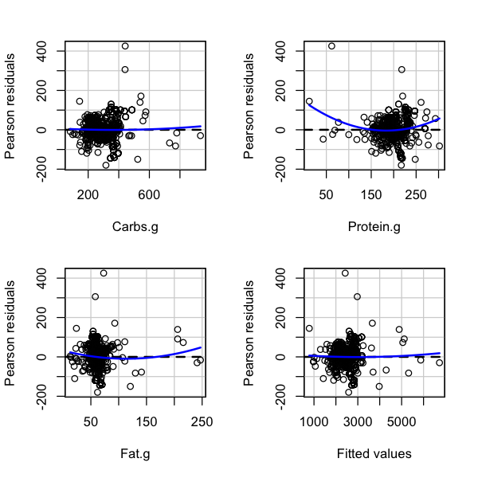

```r
fig(5, 5)
residualPlots(mod)
```

Non-constant variance seems to be an issue, but this may be due to outliers.

**Normality of Residuals**

```r
shapiro.test(mod$residuals)
```

```
	Shapiro-Wilk normality test

data:  mod$residuals
W = 0.9447, p-value = 3e-15
```

The Shapiro test indicates that the residuals are not normally distributed with $p \approx 0$.

**Outliers and Influential Points**

|  | StudRes | Hat | CookD |
| --- | --- | --- | --- |
| 418 | -0.5102739 | 0.707328189 | 0.07874707 |
| 464 | -0.7895959 | 0.586836554 | 0.11075367 |
| 567 | -1.9222939 | 0.461744099 | 0.39466296 |
| 597 | 8.7791326 | 0.234748418 | 2.65523212 |
| 680 | 5.3654904 | 0.009187548 | 0.03204536 |

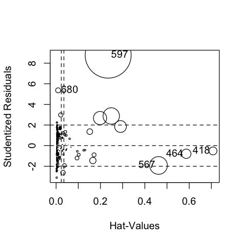

```r
fig(4, 4)
infl.pts = influencePlot(mod)
infl.pts
```

There are 5 points that are influential by their Cook's distances.

We should proceed by doing the following:

- Drop influential points. This is okay since our dataset is quite large.
- Transform $Y$, since model suffers from non-constant variance and non-normality of residuals.
- Select the best model using stepwise regression.

```r
df.inf.dropped = df[-as.integer(rownames(infl.pts)),] # drop infl points
```

0.212121212121212

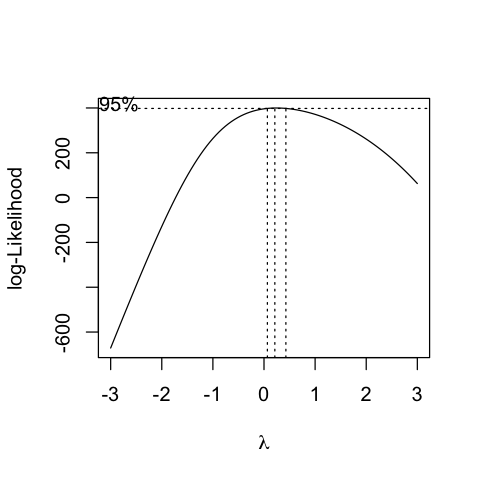

```r
fig(4, 4)
bcmle = boxcox(Calories~Carbs.g*Protein.g*Fat.g, data=df.inf.dropped, lambda=seq(-3, 3, by=0.1))
l = bcmle$x[which.max(bcmle$y)]
l
```

The optimal value for $\lambda=0.2121$, resulting in $Y'=Y^{0.2121}$.

```r
df.inf.dropped$Calories = df.inf.dropped$Calories^l
trans.mod = lm(Calories~Carbs.g*Protein.g*Fat.g, data=df.inf.dropped) # refit model
```

```r
step(trans.mod, method='both')
```

```
Start:  AIC=-5052.94
Calories ~ Carbs.g * Protein.g * Fat.g

                          Df Sum of Sq     RSS     AIC
<none>                                 0.37447 -5052.9
- Carbs.g:Protein.g:Fat.g  1   0.03079 0.40526 -5001.5
```

```
Call:
lm(formula = Calories ~ Carbs.g * Protein.g * Fat.g, data = df.inf.dropped)

Coefficients:
            (Intercept)                  Carbs.g                Protein.g
              3.394e+00                3.319e-03                5.265e-03
                  Fat.g        Carbs.g:Protein.g            Carbs.g:Fat.g
              1.375e-02               -7.464e-06               -2.355e-05
        Protein.g:Fat.g  Carbs.g:Protein.g:Fat.g
             -3.995e-05                8.606e-08
```

Stepwise regression terminates immediately, as dropping/adding other predictors only increases the AIC. The AV plots below also suggest that all predictors add value to the model and are significant.

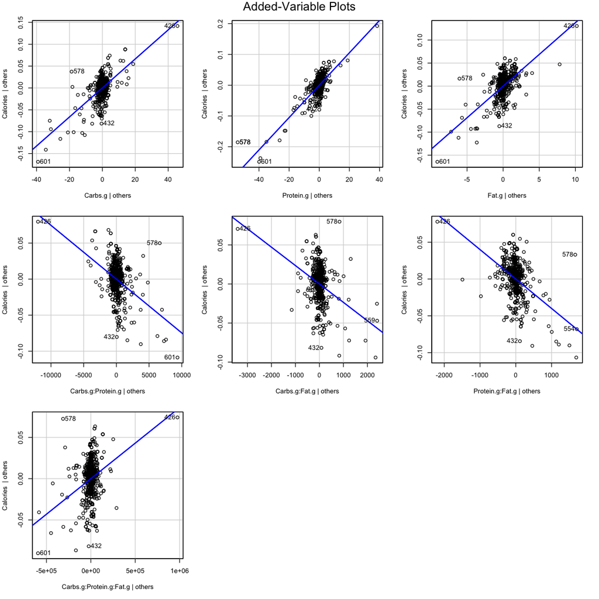

```r
fig(10, 10)
avPlots(trans.mod)
```

Thus, our final model is produced.

```r
final.mod = trans.mod
summary(final.mod)
```

```
Call:
lm(formula = Calories ~ Carbs.g * Protein.g * Fat.g, data = df.inf.dropped)

Residuals:
      Min        1Q    Median        3Q       Max
-0.079799 -0.012092  0.002319  0.011962  0.099418

Coefficients:
                          Estimate Std. Error t value Pr(>|t|)
(Intercept)              3.394e+00  3.860e-02  87.932  < 2e-16 ***
Carbs.g                  3.319e-03  1.889e-04  17.563  < 2e-16 ***
Protein.g                5.265e-03  1.830e-04  28.776  < 2e-16 ***
Fat.g                    1.375e-02  7.881e-04  17.453  < 2e-16 ***
Carbs.g:Protein.g       -7.464e-06  7.580e-07  -9.846  < 2e-16 ***
Carbs.g:Fat.g           -2.355e-05  2.980e-06  -7.903 1.12e-14 ***
Protein.g:Fat.g         -3.995e-05  3.585e-06 -11.145  < 2e-16 ***
Carbs.g:Protein.g:Fat.g  8.606e-08  1.161e-08   7.411 3.80e-13 ***
---
Signif. codes:  0 ‘***’ 0.001 ‘**’ 0.01 ‘*’ 0.05 ‘.’ 0.1 ‘ ’ 1

Residual standard error: 0.02368 on 668 degrees of freedom
Multiple R-squared:  0.9847,	Adjusted R-squared:  0.9846
F-statistic:  6157 on 7 and 668 DF,  p-value: < 2.2e-16
```

Let's test the final model on the following food items:

- McDonald's Hamburger: 250 calories, 9g fat, 31g carbs, 12g protein
- Dairy Queen Large Frosted Animal Cookie Blizzard: 1290 calories, 59g fat, 169g carbs, 21g protein
- 100g Strawberries: 33 calories, 0.3g fat, 8g carbs, 0.7g protein

```r
new.data = data.frame(matrix(rbind(c(250, 9, 31, 12), c(1290, 59, 169, 21), c(33, 0.3, 8, 0.7)), ncol=4, nrow=3))
colnames(new.data) = c('Calories', 'Fat.g', 'Carbs.g', 'Protein.g')

predict(final.mod, new.data)
```

**1**

3.67076710238989

**2**

4.58438441296084

**3**

3.42855552281521

Since we transformed $Y$, we must back-transform to extract predictions in the same unit as the original data.

```r
predict(final.mod, new.data)^(1/l)
```

**1**

459.64766670239

**2**

1310.59256501258

**3**

333.170870899167

```r
predict(mod, new.data)
```

**1**

252.653572421217

**2**

1285.51984859954

**3**

19.3459503287927

Maybe, we can try WLS regression, instead of transforming $Y$, to correct non-constant variance and result in a better model.

```r
df.inf.dropped$Calories = df.inf.dropped$Calories^(1/l) # undo transformation to fit WLS model

ols.mod = lm(Calories~Carbs.g*Protein.g*Fat.g, data=df.inf.dropped)
print(summary(ols.mod))
for (i in 1:10000) {
    weights = 1/fitted(lm(abs(ols.mod$residuals)~Carbs.g*Protein.g*Fat.g, data=df.inf.dropped))^2
    wls.mod = lm(Calories~Carbs.g*Protein.g*Fat.g, data=df.inf.dropped, weights=weights)
    if (sum(abs((wls.mod$coefficients - ols.mod$coefficients)) < 0.8) == 8) {
        print(paste("num iterations:", i))
        #print(summary(ols.mod))
        print(summary(wls.mod))
        break
    }
    ols.mod = wls.mod
}
```

```
Call:
lm(formula = Calories ~ Carbs.g * Protein.g * Fat.g, data = df.inf.dropped)

Residuals:
     Min       1Q   Median       3Q      Max
-180.121  -23.728    1.776   26.616  184.783

Coefficients:
                          Estimate Std. Error t value Pr(>|t|)
(Intercept)              1.299e+01  8.738e+01   0.149  0.88183
Carbs.g                  2.639e+00  4.277e-01   6.170 1.19e-09 ***
Protein.g                5.094e+00  4.141e-01  12.301  < 2e-16 ***
Fat.g                    1.536e+01  1.784e+00   8.610  < 2e-16 ***
Carbs.g:Protein.g        1.833e-03  1.716e-03   1.069  0.28567
Carbs.g:Fat.g           -1.233e-02  6.745e-03  -1.828  0.06804 .
Protein.g:Fat.g         -4.002e-02  8.115e-03  -4.932 1.03e-06 ***
Carbs.g:Protein.g:Fat.g  7.827e-05  2.629e-05   2.978  0.00301 **
---
Signif. codes:  0 ‘***’ 0.001 ‘**’ 0.01 ‘*’ 0.05 ‘.’ 0.1 ‘ ’ 1

Residual standard error: 53.59 on 668 degrees of freedom
Multiple R-squared:  0.9837,	Adjusted R-squared:  0.9835
F-statistic:  5766 on 7 and 668 DF,  p-value: < 2.2e-16

[1] "num iterations: 9550"

Call:
lm(formula = Calories ~ Carbs.g * Protein.g * Fat.g, data = df.inf.dropped,
    weights = weights)

Weighted Residuals:
    Min      1Q  Median      3Q     Max
-7.0447 -0.7347  0.0715  0.7950  4.8226

Coefficients:
                          Estimate Std. Error t value Pr(>|t|)
(Intercept)             -6.302e+01  1.073e+02  -0.587    0.557
Carbs.g                  3.767e+00  4.633e-01   8.130 2.09e-15 ***
Protein.g                5.102e+00  5.466e-01   9.335  < 2e-16 ***
Fat.g                    1.021e+01  1.664e+00   6.139 1.43e-09 ***
Carbs.g:Protein.g       -2.962e-03  2.076e-03  -1.427    0.154
Carbs.g:Fat.g           -7.738e-03  6.529e-03  -1.185    0.236
Protein.g:Fat.g         -8.425e-03  8.651e-03  -0.974    0.330
Carbs.g:Protein.g:Fat.g  4.457e-05  2.766e-05   1.611    0.108
---
Signif. codes:  0 ‘***’ 0.001 ‘**’ 0.01 ‘*’ 0.05 ‘.’ 0.1 ‘ ’ 1

Residual standard error: 1.417 on 668 degrees of freedom
Multiple R-squared:  0.9853,	Adjusted R-squared:  0.9851
F-statistic:  6378 on 7 and 668 DF,  p-value: < 2.2e-16
```

The WLS model produces has the highest $R^2_{adj=0.9851}$, amongst all models. Let's test how it performs during prediction.

```r
predict(wls.mod, new.data)
```

**1**

202.878826103692

**2**

1194.5380779721

**3**

-26.287074969259

Apparently, it doesn't perform well during prediction. Despite the original OLS model violating some assumptions (normality and heteroskedasticity of residuals), it still poses to be the best model for prediction.

Let's perform CV to verify this.

```r
train.control = trainControl(method='cv', number=5)

# original mod
mod1 = train(Calories~Carbs.g*Protein.g*Fat.g, data=df, method='leapBackward', tuneGrid=data.frame(nvmax=7), trControl=train.control)
mod1$results$Rsquared = c(0.98983293)
mod1$results

# transformed mod
df.inf.dropped$Calories = df.inf.dropped$Calories^l # apply transformation
mod2 = train(Calories~Carbs.g*Protein.g*Fat.g, data=df.inf.dropped, method='leapBackward', tuneGrid=data.frame(nvmax=7), trControl=train.control)
mod2$results

# WLS mod
df.inf.dropped$Calories = df.inf.dropped$Calories^(1/l) # undo transformation
mod3 = train(Calories~Carbs.g*Protein.g*Fat.g, data=df.inf.dropped, weights=wls.mod$weights, method='leapBackward', tuneGrid=data.frame(nvmax=7), trControl=train.control)
mod3$results
```

| nvmax | RMSE | Rsquared | MAE | RMSESD | RsquaredSD | MAESD |
| --- | --- | --- | --- | --- | --- | --- |
| 7 | 60.55244 | 0.9898329 | 42.18535 | 6.978411 | 0.006018136 | 1.00875 |

| nvmax | RMSE | Rsquared | MAE | RMSESD | RsquaredSD | MAESD |
| --- | --- | --- | --- | --- | --- | --- |
| 7 | 0.02416189 | 0.9840232 | 0.01784881 | 0.001231526 | 0.002462678 | 0.00150286 |

| nvmax | RMSE | Rsquared | MAE | RMSESD | RsquaredSD | MAESD |
| --- | --- | --- | --- | --- | --- | --- |
| 7 | 56.60187 | 0.9808054 | 41.03011 | 3.724986 | 0.006613421 | 2.768276 |

**Conclusion**

Some potential issues include the following:

- Nutrition fact labels vary depending on the source. Some claim that 100g of strawberries has 33 calories, while others claim it may have 40. These discrepancies can make model evaluation difficult and unrealiable.

Navigate to the top.